# 폐암(Lung) 임상 코호트 분석

**목표.** 진행 중인 폐암(Lung) 임상 코호트를 ClinicalTrials.gov 전량 수집 데이터로 분석하여, (1) 표준치료 **B(대조군/backbone)** 데이터 자산을 수요 폭 기준으로 우선순위화하고, (2) **코호트 유사도 2D 맵 + 군집화**로 제약사들이 집중하는 코호트 분포를 시각화한다. 빅파마 참여 임상을 강조 표시해 **먼저 접근할 코호트**를 선별한다.

핵심 통찰: `A + B vs B`(또는 `A vs B`) 구조에서 **B는 표준치료**이며, 스폰서들은 공통적으로 "B 치료에 따른 종양미세환경(TME) 변화·반응 바이오마커"를 원한다 → B의 실제 TME 데이터는 그 B를 쓰는 진행 중 임상이 많을수록 가치가 높다.

```
Lung: industry-led trials 1070 / 1335 (academic/other excluded)
```

|  | nct_id | brief_title | phase | phase_simple | overall_status | enrollment | lead_sponsor | company | sponsor_scale | is_industry | ... | is_combination | EGFR_mut | ALK | ROS1 | KRAS_G12C | MET | PD-L1 | first_line | later_line | biomarker_selected |
| --- | --- | --- | --- | --- | --- | --- | --- | --- | --- | --- | --- | --- | --- | --- | --- | --- | --- | --- | --- | --- | --- |
| 0 | NCT01064466 | Pharmacogenomics ANDA SNP Clinical Study - Eto... | PHASE2;PHASE3 | Phase 3 | ACTIVE_NOT_RECRUITING | 600 | Han Xu, M.D., Ph.D., FAPCR, Medical Director,,... | Han Xu, M.D., Ph.D., FAPCR, Medical Director,,... | 3 | 1 | ... | 1 | 0 | 0 | 0 | 0 | 0 | 0 | 0 | 0 | 0 |
| 1 | NCT01394679 | A Phase 3 Study of 99mTC-EC-DG SPECT/CT Versus... | PHASE3 | Phase 3 | NOT_YET_RECRUITING | 154 | Cell>Point LLC | Cell>Point | 3 | 1 | ... | 1 | 0 | 0 | 0 | 0 | 0 | 0 | 0 | 0 | 0 |
| 2 | NCT01933932 | Assess Efficacy & Safety of Selumetinib in Com... | PHASE3 | Phase 3 | ACTIVE_NOT_RECRUITING | 510 | AstraZeneca | AstraZeneca | 780 | 1 | ... | 1 | 0 | 0 | 0 | 0 | 0 | 0 | 1 | 0 | 0 |

3 rows × 29 columns

## 1. EDA — 수집 데이터 분포 점검

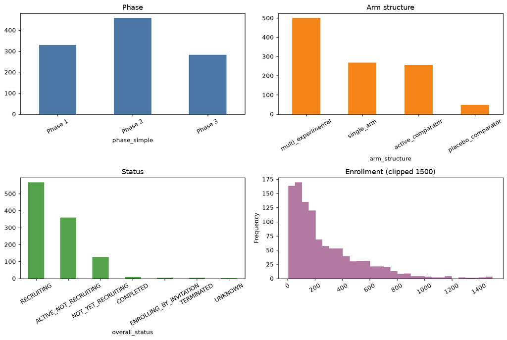

```
Industry-led: 1070 | Big pharma involved: 366
TME-relevant modality: 597 | Biomarker-selected eligibility: 563
```

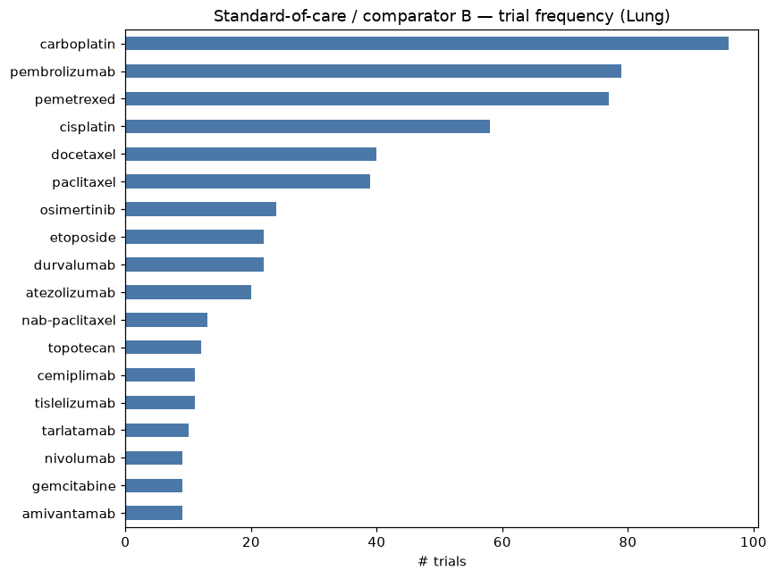

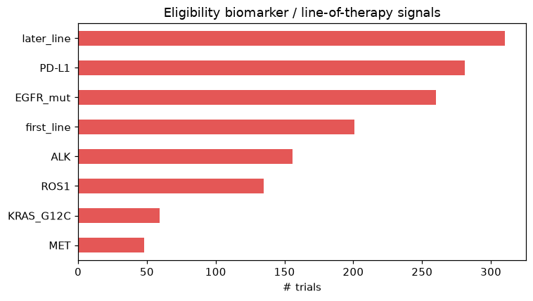

## 1-B. 표준치료(SoC) 대조군 코호트 분류 (정규화 보정 포함)

각 임상의 대조군/backbone을 스캔해 **확립된 표준치료(SoC)가 있는 코호트**와 아닌 것으로 나눈다. 레지멘 변형(`FLOT regimen`), 복합 표기(`trastuzumab + XELOX`), generic 표기(`standard of care`, `investigator's choice`)까지 substring으로 인식해 정규화 누락을 보정한다. 비-SoC는 ① 대조군 없음(단일군/비대조), ② novel 신약만, ③ 비약물(수술·기기·진단)으로 세분한다.

```
cohort_class
novel drug only (no SoC)        668
SoC-anchored                    376
non-drug (surgery/device/dx)     26

SoC-anchored: 376 / 1070
```

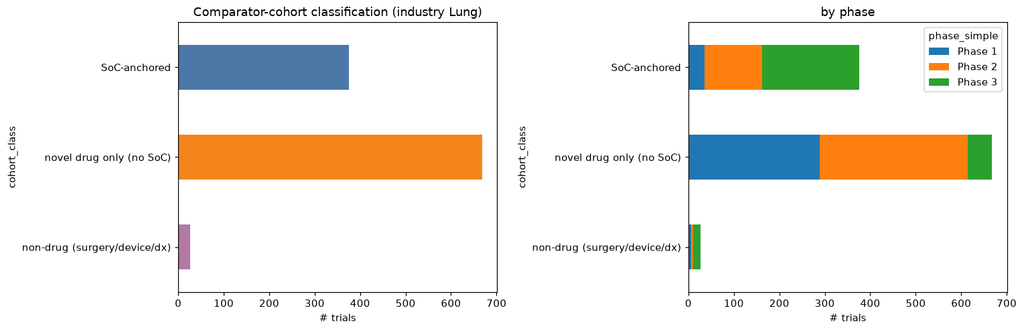

```
SoC-anchored 코호트의 치료 계열 분포:
soc_class
chemo              128
IO                  89
IO;chemo            78
EGFR_TKI            36
ALK/ROS1_TKI        13
EGFR_TKI;chemo       8
anti_VEGF;chemo      4
SoC_generic          4
KRAS_G12Ci           3
MET_TKI              2
anti_VEGF            2
IO;MET_TKI           1
```

## 2. Feature engineering — 표준치료 **성분(component)** 인코딩

**바이오마커·타겟·모달리티·arm 구조 등은 제외.** SoC-anchored 코호트만 남긴다. 군집화 feature는 표준치료를 **성분 약물 수준**으로 인코딩한다(FOLFOX→5FU+leucovorin+oxaliplatin). 이유: 레지멘을 원자 feature로 두면 "3개 중 2개만" 쓴 케이스나 유사 레지멘이 코사인 유사도 0으로 분리되지만, 성분으로 두면 **부분 겹침이 반영**돼 임상적으로 가까운 코호트가 가깝게 위치한다. 레지멘 라벨(`B_soc`)은 클러스터 해석·카드 표시용으로만 유지.

```
standard-of-care anchored cohorts: 376  (from 1070 industry Lung trials)
feature matrix (SoC components): (376, 44)
성분 feature: ['B=adagrasib', 'B=afatinib', 'B=alectinib', 'B=atezolizumab', 'B=bevacizumab', 'B=binimetinib', 'B=capecitabine', 'B=capmatinib', 'B=carboplatin', 'B=cemiplimab', 'B=ceritinib', 'B=cisplatin', 'B=crizotinib', 'B=docetaxel', 'B=dostarlimab', 'B=durvalumab', 'B=encorafenib', 'B=entrectini…
```

## 2-B. 레지멘 수준 데이터 (별도 표시)

군집은 성분 기반이지만, 사람이 읽기 좋은 **레지멘 관점**으로도 따로 집계한다: 각 코호트의 **화학요법 backbone**과 **추가 표적·면역 약물**(+anti-VEGF/+anti-EGFR/+IO/+HER2/+CLDN18.2)을 조합해 분포를 본다.

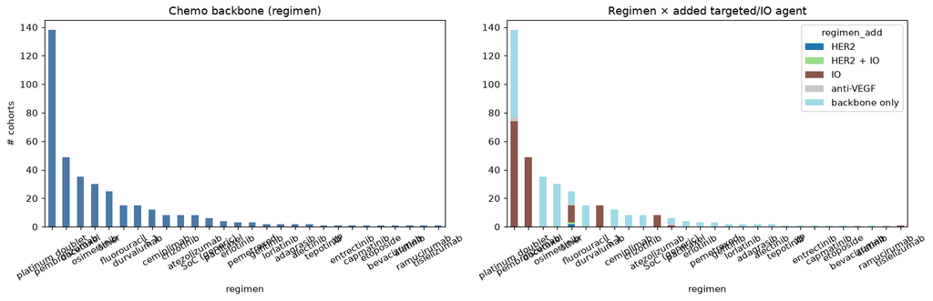

```
레지멘 × 추가약물 교차표:
regimen_add       HER2  HER2 + IO  IO  anti-VEGF  backbone only
regimen
S-1                  0          0   0          0             12
SoC (generic)        0          0   1          1              4
XP                   0          0   0          0              1
adagrasib            0          0   0          0              2
afatinib             0          0   0          0              1
alectinib            0          0   0          0              2
atezolizumab         0          0   8          0              0
bevacizumab          0          0   0          1              0
capmatinib           0          0   0          0              1
cemiplimab           0          0   0          0              8
crizotinib           0          0   0          0              8
docetaxel            0          0   0          0             35
durvalumab           0          0  15          0              0
entrectinib          0          0   0          0              1
erlotinib            0          0   0          0              3
etoposide            0          0   0          0              1
fluorouracil         0          0   0          0             15
gefitinib            0          0   0          0              2
lorlatinib           0          0   0          0              2
osimertinib          0          0   0          0             30
other                2          1  12          1              9
paclitaxel           0          0   0          0              4
pembrolizumab        0          0  49          0              0
pemetrexed           0          0   0          0              3
platinum doublet     0          0  74          3             61
ramucirumab          0          0   0          1              0
tepotinib            0          0   0          0              1
tislelizumab         0          0   1          0              0
```

## 3. 차원축소 & 군집화 — 치료구성 cosine 공간에서 KMeans (silhouette로 k 선택)

```
k=4  silhouette=0.348  sizes=[np.int64(147), np.int64(128), np.int64(60), np.int64(41)]
k=5  silhouette=0.417  sizes=[np.int64(139), np.int64(104), np.int64(59), np.int64(41), np.int64(33)]
k=6  silhouette=0.429  sizes=[np.int64(115), np.int64(93), np.int64(60), np.int64(41), np.int64(34), np.int64(33)]
k=7  silhouette=0.471  sizes=[np.int64(120), np.int64(93), np.int64(59), np.int64(41), np.int64(33), np.int64(18), np.int64(12)]
k=8  silhouette=0.491  sizes=[np.int64(120), np.int64(65), np.int64(60), np.int64(41), np.int64(33), np.int64(27), np.int64(18), np.int64(12)]
k=9  silhouette=0.512  sizes=[np.int64(106), np.int64(59), np.int64(58), np.int64(40), np.int64(34), np.int64(33), np.int64(17), np.int64(17), np.int64(12)]
chosen k = 9
```

## 4. 클러스터 프로파일링 — 아키타입 명명

|  | cluster | n | top_B | top_target | top_modality | phase_mix | bigpharma | biomarker_sel% |
| --- | --- | --- | --- | --- | --- | --- | --- | --- |
| 0 | 0 | 106 | pemetrexed, carboplatin, cisplatin | PD-1, EGFR, PD-L1 | Monoclonal Antibody, Small Molecule, ADC | Phase 3:77, Phase 2:28, Phase 1:1 | 66 | 78 |
| 1 | 1 | 58 | cemiplimab, atezolizumab, crizotinib | PD-L1, ALK, EGFR | Small Molecule, Monoclonal Antibody, ADC | Phase 3:28, Phase 2:27, Phase 1:3 | 25 | 71 |
| 2 | 2 | 40 | docetaxel, ramucirumab, pemetrexed | PD-1, KRAS, PD-L1 | Small Molecule, ADC, Monoclonal Antibody | Phase 3:30, Phase 2:9, Phase 1:1 | 14 | 80 |
| 3 | 3 | 33 | osimertinib, fluorouracil, pemetrexed | EGFR, MET, TROP2 | Small Molecule, ADC, Monoclonal Antibody | Phase 2:17, Phase 3:13, Phase 1:3 | 12 | 85 |
| 4 | 4 | 17 | durvalumab, savolitinib, carboplatin | PD-L1, 5T4, ALK | Monoclonal Antibody, Small Molecule, Bispecifi... | Phase 2:9, Phase 3:7, Phase 1:1 | 15 | 76 |
| 5 | 5 | 34 | carboplatin, etoposide, atezolizumab | PD-L1, PD-1, VEGF/VEGFR | Monoclonal Antibody, Small Molecule, ADC | Phase 3:24, Phase 2:7, Phase 1:3 | 13 | 38 |
| 6 | 6 | 17 | fluorouracil, trastuzumab, tucatinib | EGFR, PD-1, HER2 | Small Molecule, ADC, Cell Therapy | Phase 2:10, Phase 1:5, Phase 3:2 | 2 | 47 |
| 7 | 7 | 12 | s-1 | EGFR, MET, RET | Small Molecule, ADC | Phase 1:9, Phase 2:3 | 0 | 42 |
| 8 | 8 | 59 | pembrolizumab, nivolumab, durvalumab | PD-1, HER2, ER | Monoclonal Antibody, Small Molecule, ADC | Phase 3:33, Phase 2:17, Phase 1:9 | 32 | 75 |

## 5. 코호트 유사도 2D 맵 — 클러스터 · Phase · 빅파마 강조

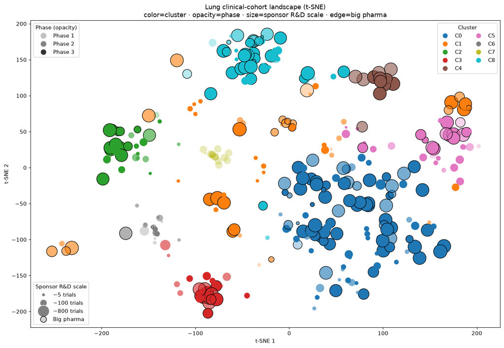

## 5-B. 클러스터별 대표 빅파마 코호트

```
saved outputs/cluster_representatives_lung.csv
```

|  | cluster | n | 대표 제약사 | 대조군 치료 B | 바이오마커 | phase | 대표 NCT | 다른 제약사 |
| --- | --- | --- | --- | --- | --- | --- | --- | --- |
| 0 | 0 | 106 | Takeda | carboplatin;cisplatin;pemetrexed | EGFR_mut | Phase 3 | NCT04129502 | AstraZeneca, Hoffmann-La Roche, Merck Sharp & Dohme LLC,... |
| 1 | 1 | 58 | Regeneron Pharmaceuticals | cemiplimab | ALK, ROS1 | Phase 2 | NCT03916627 | Eli Lilly and Company, Novartis Pharmaceuticals, Hoffman... |
| 2 | 2 | 40 | AstraZeneca | docetaxel | - | Phase 3 | NCT01933932 | GlaxoSmithKline, Daiichi Sankyo, Mirati Therapeutics Inc... |
| 3 | 3 | 33 | AstraZeneca | osimertinib | EGFR_mut | Phase 2 | NCT03239340 | Ascentage Pharma Group Inc., Janssen Research & Developm... |
| 4 | 4 | 17 | AstraZeneca | durvalumab | PD-L1 | Phase 2 | NCT03693300 | NeoTX Therapeutics Ltd., Hoffmann-La Roche, Innate Pharm... |
| 5 | 5 | 34 | Hoffmann-La Roche | atezolizumab;carboplatin;etoposide | - | Phase 3 | NCT04665856 | AstraZeneca, Prestige Biopharma Limited, EpicentRx, Inc.... |
| 6 | 6 | 17 | Asher Biotherapeutics, Inc. | fluorouracil | - | Phase 1 | NCT05653882 | BioEclipse Therapeutics, Seagen, a wholly owned subsidia... |
| 7 | 7 | 12 | Jiangsu Hansoh Pharmaceutical Co., Ltd. (빅파마 없음·최근접) | s-1 | EGFR_mut | Phase 1 | NCT05430386 | Volastra Therapeutics, Inc., TwoStep Therapeutics, Inc. |
| 8 | 8 | 59 | Merck Sharp & Dohme LLC | pembrolizumab | PD-L1 | Phase 2 | NCT02628067 | Eli Lilly and Company, Precision Biologics, Inc, Nanobio... |

## 5-C. 인터랙티브 코호트 대시보드 (HTML)

`outputs/cohort_map_<slug>.html` — 좌: 코호트 맵, 우: ① 클러스터별 정보, ② **R&D 규모순 제약사 드롭다운** → 선택 시 맵에서 위치 하이라이트 + 그 제약사 임상의 ClinicalTrials.gov 링크·상세 카드. 맵의 점 클릭·hover(제약사·레지멘·Phase·status)도 지원.

```
saved /Users/minsung.choi/clinical_data_finder/outputs/cohort_map_lung.html
```

## 6. 가치 랭킹 — 표준치료 B 데이터 자산 (수요 폭 중심)

각 B에 대해: **demand_breadth**(그 B를 쓰는 진행 중 트라이얼 수, 주축) + 스폰서 다양성 + 빅파마 수 + phase 가중 + 등록 규모 + TME 관련성 + 바이오마커 개방성.

|  | B (standard therapy) | demand_breadth | sponsors | bigpharma | phase_weight | n_phase3 | enroll_sum | tme_rel% | biomarker% | value_score |
| --- | --- | --- | --- | --- | --- | --- | --- | --- | --- | --- |
| 0 | carboplatin | 135 | 58 | 78 | 349.4 | 97 | 60927 | 69 | 67 | 0.970152 |
| 1 | pemetrexed | 104 | 46 | 64 | 274.2 | 77 | 50198 | 65 | 78 | 0.783986 |
| 2 | pembrolizumab | 100 | 49 | 63 | 245.0 | 65 | 49505 | 84 | 73 | 0.773173 |
| 3 | cisplatin | 86 | 35 | 57 | 235.0 | 70 | 42218 | 67 | 72 | 0.664589 |
| 4 | paclitaxel | 53 | 26 | 36 | 134.6 | 36 | 27217 | 81 | 75 | 0.462224 |
| 5 | docetaxel | 44 | 39 | 17 | 114.6 | 32 | 18465 | 64 | 80 | 0.419153 |
| 6 | osimertinib | 38 | 19 | 15 | 81.4 | 16 | 10768 | 32 | 87 | 0.310703 |
| 7 | etoposide | 29 | 20 | 15 | 72.6 | 20 | 10326 | 86 | 31 | 0.281810 |
| 8 | durvalumab | 25 | 13 | 21 | 57.6 | 13 | 8400 | 84 | 68 | 0.265886 |
| 9 | atezolizumab | 23 | 17 | 16 | 55.2 | 14 | 6296 | 91 | 43 | 0.250612 |
| 10 | nab-paclitaxel | 17 | 8 | 15 | 42.6 | 11 | 9146 | 88 | 76 | 0.217013 |
| 11 | gemcitabine | 15 | 5 | 13 | 40.8 | 12 | 10456 | 80 | 87 | 0.200755 |
| 12 | tislelizumab | 13 | 10 | 1 | 36.2 | 11 | 5928 | 77 | 62 | 0.168408 |
| 13 | fluorouracil | 19 | 16 | 2 | 30.2 | 2 | 3130 | 32 | 47 | 0.167826 |
| 14 | cemiplimab | 11 | 6 | 8 | 21.8 | 3 | 1328 | 73 | 82 | 0.146080 |

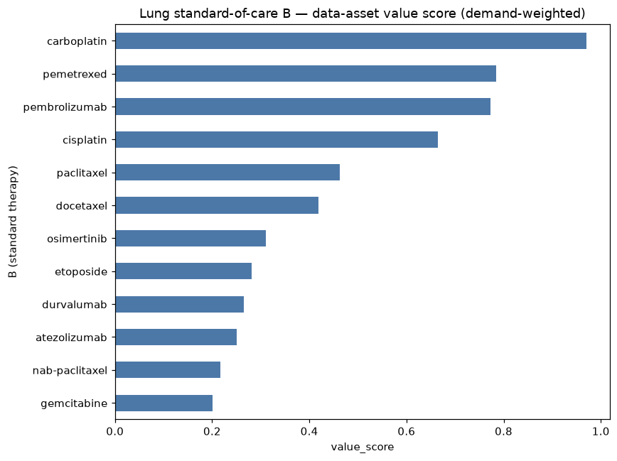

## 7. 먼저 접근할 코호트 — 빅파마 참여 + Phase 3 우선

|  | nct_id | phase_simple | lead_sponsor | B_soc | targets | enrollment | arm_structure | biomarker_selected |
| --- | --- | --- | --- | --- | --- | --- | --- | --- |
| 235 | NCT06712316 | Phase 3 | BioNTech SE | carboplatin;paclitaxel;pembrolizumab;pemetrexed | PD-1 | 1580 | active_comparator | 0 |
| 307 | NCT07222566 | Phase 3 | Pfizer | pembrolizumab | PD-1 | 1410 | active_comparator | 1 |
| 128 | NCT05687266 | Phase 3 | AstraZeneca | carboplatin;cisplatin;paclitaxel;pembrolizumab;pemetrexed | PD-L1 | 1350 | active_comparator | 1 |
| 5 | NCT02486718 | Phase 3 | Hoffmann-La Roche | cisplatin;docetaxel;gemcitabine;pemetrexed;vinorelbine | PD-L1 | 1280 | active_comparator | 1 |
| 167 | NCT06119581 | Phase 3 | Eli Lilly and Company | carboplatin;cisplatin;pembrolizumab;pemetrexed | KRAS | 1264 | placebo_comparator | 1 |
| 15 | NCT03164616 | Phase 3 | AstraZeneca | carboplatin;cisplatin;gemcitabine;nab-paclitaxel;pemetrexed | PD-L1 | 1186 | active_comparator | 1 |
| 115 | NCT05555732 | Phase 3 | Daiichi Sankyo | carboplatin;cisplatin;pembrolizumab;pemetrexed | PD-1 | 1170 | active_comparator | 1 |
| 224 | NCT06627647 | Phase 3 | AstraZeneca | carboplatin;cisplatin;pembrolizumab;pemetrexed | PD-1 | 1160 | active_comparator | 1 |
| 232 | NCT06692738 | Phase 3 | AstraZeneca | carboplatin;nab-paclitaxel;paclitaxel;pembrolizumab | PD-1 | 1160 | active_comparator | 1 |
| 4 | NCT02453282 | Phase 3 | AstraZeneca | carboplatin;cisplatin;gemcitabine;paclitaxel;pemetrexed | PD-L1 | 1118 | active_comparator | 1 |
| 48 | NCT04487080 | Phase 3 | Janssen Research & Development, LLC | osimertinib | EGFR | 1074 | active_comparator | 1 |
| 86 | NCT05221840 | Phase 3 | AstraZeneca | durvalumab | PD-L1 | 1051 | active_comparator | 1 |
| 111 | NCT05502237 | Phase 3 | Gilead Sciences | carboplatin;cisplatin;nab-paclitaxel;paclitaxel;pembroli... | PD-1 | 1021 | active_comparator | 1 |
| 16 | NCT03178552 | Phase 3 | Hoffmann-La Roche | carboplatin;cisplatin;gemcitabine;pemetrexed | ALK | 1000 | active_comparator | 0 |
| 214 | NCT06561386 | Phase 3 | Bristol-Myers Squibb | carboplatin;cisplatin;pembrolizumab;pemetrexed | PD-1 | 1000 | active_comparator | 1 |
| 13 | NCT03043872 | Phase 3 | AstraZeneca | carboplatin;cisplatin;etoposide | PD-L1 | 987 | active_comparator | 0 |
| 6 | NCT02542293 | Phase 3 | AstraZeneca | carboplatin;cisplatin;gemcitabine;paclitaxel;pemetrexed | PD-L1 | 953 | active_comparator | 1 |
| 369 | NCT07756645 | Phase 3 | AbbVie | carboplatin;paclitaxel | PD-1 | 940 | multi_experimental | 1 |
| 153 | NCT05984277 | Phase 3 | AstraZeneca | carboplatin;paclitaxel;pembrolizumab;pemetrexed | PD-1 | 895 | active_comparator | 1 |
| 47 | NCT04380636 | Phase 3 | Merck Sharp & Dohme LLC | carboplatin;cisplatin;durvalumab;etoposide;paclitaxel;pe... | PD-1 | 870 | active_comparator | 1 |

## 8. 요약

- **가치 랭킹(`outputs/value_ranking_lung.csv`)**: 폐암(Lung)에서 TME 데이터를 만들면 가장 많은 스폰서가 원할 표준치료 B 순위.
- **코호트 맵/대시보드(`outputs/cohort_map_lung.png` / `.html`)**: 제약사들이 집중하는 코호트 아키타입 분포, Phase·빅파마 강조.
- **먼저 접근할 코호트**: 빅파마 참여 + Phase 3 pivotal 우선.